# Régressions linéaires sur R

Antoine Sireyjol

20 janvier 2020

## Interprétation des modèles de régression

Avant de se lancer dans des régressions, il est important de vérifier les propriétés des variables à notre disposition, comme vous avez pu le faire dans le projet. En effet, des résultats identiques en termes de régression peuvent en fait cacher des données très différentes. Pour illustrer cela, vous pouvez charger les données d’Anscombe comme ceci :

```r
anscombe <- datasets::anscombe
```

Dans R, la régression linéaire se fait avec `lm()`

0. Lisez attentivement la documentation de `lm`, les paramètres à renseigner, les valeurs qu’on peut obtenir en sortie…
1. Comparez maintenant les sorties des régressions de y1 sur x1, y2 sur x2, y3 sur x3 et y4 sur x4. Que constatez-vous?

**Correction** : Les régressions de yi sur xi donnent :

```r
mod1 <- lm(data = anscombe, y1 ~ x1)
summary(mod1)
```

```
##
## Call:
## lm(formula = y1 ~ x1, data = anscombe)
##
## Residuals:
##      Min       1Q   Median       3Q      Max
## -1.92127 -0.45577 -0.04136  0.70941  1.83882
##
## Coefficients:
##             Estimate Std. Error t value Pr(>|t|)
## (Intercept)   3.0001     1.1247   2.667  0.02573 *
## x1            0.5001     0.1179   4.241  0.00217 **
## ---
## Signif. codes:  0 '***' 0.001 '**' 0.01 '*' 0.05 '.' 0.1 ' ' 1
##
## Residual standard error: 1.237 on 9 degrees of freedom
## Multiple R-squared:  0.6665, Adjusted R-squared:  0.6295
## F-statistic: 17.99 on 1 and 9 DF,  p-value: 0.00217
```

```r
mod2 <- lm(data= anscombe, y2 ~ x2)
summary(mod2)
```

```
##
## Call:
## lm(formula = y2 ~ x2, data = anscombe)
##
## Residuals:
##     Min      1Q  Median      3Q     Max
## -1.9009 -0.7609  0.1291  0.9491  1.2691
##
## Coefficients:
##             Estimate Std. Error t value Pr(>|t|)
## (Intercept)    3.001      1.125   2.667  0.02576 *
## x2             0.500      0.118   4.239  0.00218 **
## ---
## Signif. codes:  0 '***' 0.001 '**' 0.01 '*' 0.05 '.' 0.1 ' ' 1
##
## Residual standard error: 1.237 on 9 degrees of freedom
## Multiple R-squared:  0.6662, Adjusted R-squared:  0.6292
## F-statistic: 17.97 on 1 and 9 DF,  p-value: 0.002179
```

```r
mod3 <- lm(data= anscombe, y3 ~ x3)
summary(mod3)
```

```
##
## Call:
## lm(formula = y3 ~ x3, data = anscombe)
##
## Residuals:
##     Min      1Q  Median      3Q     Max
## -1.1586 -0.6146 -0.2303  0.1540  3.2411
##
## Coefficients:
##             Estimate Std. Error t value Pr(>|t|)
## (Intercept)   3.0025     1.1245   2.670  0.02562 *
## x3            0.4997     0.1179   4.239  0.00218 **
## ---
## Signif. codes:  0 '***' 0.001 '**' 0.01 '*' 0.05 '.' 0.1 ' ' 1
##
## Residual standard error: 1.236 on 9 degrees of freedom
## Multiple R-squared:  0.6663, Adjusted R-squared:  0.6292
## F-statistic: 17.97 on 1 and 9 DF,  p-value: 0.002176
```

```r
mod4 <- lm(data= anscombe, y4 ~ x4)
summary(mod4)
```

```
##
## Call:
## lm(formula = y4 ~ x4, data = anscombe)
##
## Residuals:
##    Min     1Q Median     3Q    Max
## -1.751 -0.831  0.000  0.809  1.839
##
## Coefficients:
##             Estimate Std. Error t value Pr(>|t|)
## (Intercept)   3.0017     1.1239   2.671  0.02559 *
## x4            0.4999     0.1178   4.243  0.00216 **
## ---
## Signif. codes:  0 '***' 0.001 '**' 0.01 '*' 0.05 '.' 0.1 ' ' 1
##
## Residual standard error: 1.236 on 9 degrees of freedom
## Multiple R-squared:  0.6667, Adjusted R-squared:  0.6297
## F-statistic:    18 on 1 and 9 DF,  p-value: 0.002165
```

Les coefficients des xi, leur significativité et le R2 associé sont identiques dans chacune des 4 régressions.

2. Représentez les nuages de points et les droites de régression correspondantes.

**Correction** : Une des manières de représenter le nuage de points et la droite de régression associée serait la suivante :

```r
library(dplyr)
```

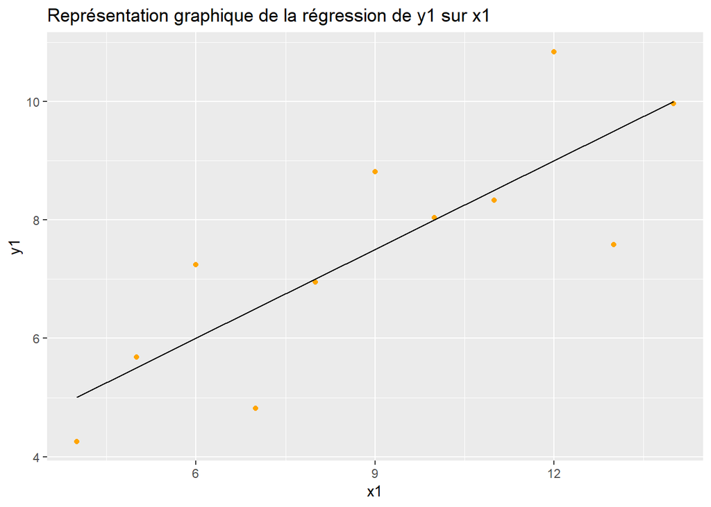

```r
# on crée les variables prédites par la droite de régression avec predict()
anscombe <- anscombe %>%
  mutate(x1_pred = predict(mod1),
         x2_pred = predict(mod2),
         x3_pred = predict(mod3),
         x4_pred = predict(mod4))

# on représente le nuage de points et la droite avec ggplot2
library(ggplot2)
anscombe %>% ggplot() +
  geom_point(aes(y = y1, x = x1), color = "orange") + # pour les points
  geom_line(aes(y = x1_pred, x = x1)) + # pour la droite de régression
  labs(title = "Représentation graphique de la régression de y1 sur x1")
```

De même pour y2, y3 et y4 :

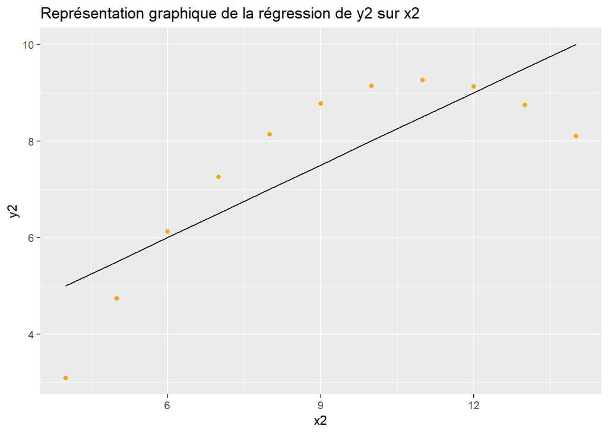

```r
# y2
anscombe %>% ggplot() +
  geom_point(aes(y = y2, x = x2), color = "orange") + # pour les points
  geom_line(aes(y = x2_pred, x = x2)) + # pour la droite de régression
  labs(title = "Représentation graphique de la régression de y2 sur x2")
```

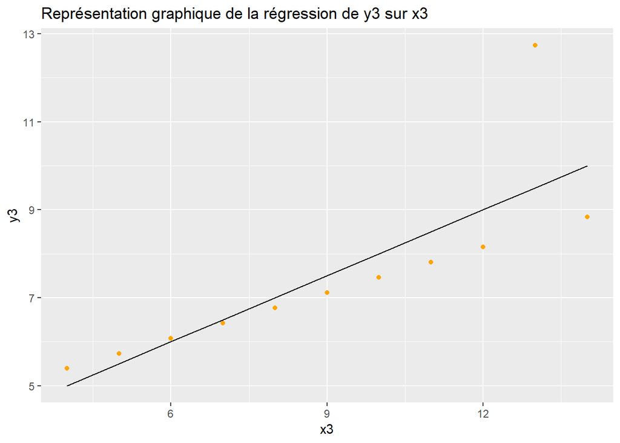

```r
# y3
anscombe %>% ggplot() +
  geom_point(aes(y = y3, x = x3), color = "orange") + # pour les points
  geom_line(aes(y = x3_pred, x = x3)) + # pour la droite de régression
  labs(title = "Représentation graphique de la régression de y3 sur x3")
```

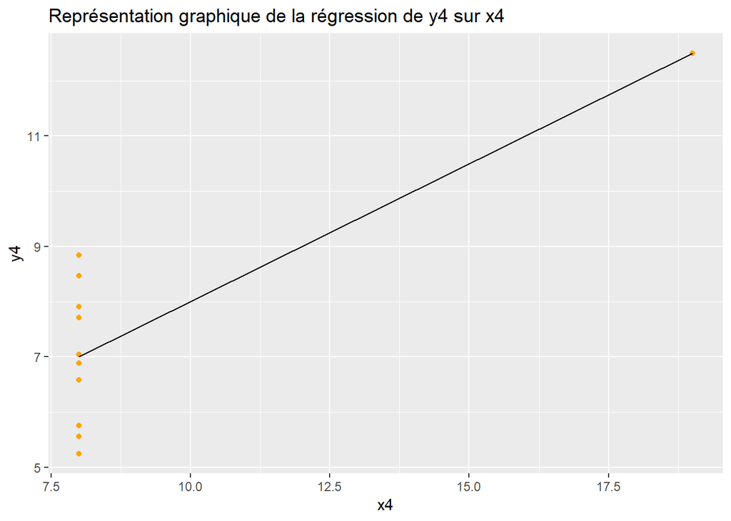

```r
# y4
anscombe %>% ggplot() +
  geom_point(aes(y = y4, x = x4), color = "orange") + # pour les points
  geom_line(aes(y = x4_pred, x = x4)) + # pour la droite de régression
  labs(title = "Représentation graphique de la régression de y4 sur x4")
```

3. Représentez la distribution des résidus de chacun de ces modèles.

**Correction** : La représentation graphique des résidus peut nous indiquer si la régression linéaire est pertinente par rapport aux données. Une hypothèse fondamentale est en effet que les résidus soient normalement distribués autour de 0 (= suivent une loi normale centrée réduite). Plutôt que `ggplot2`, on va utiliser directement les fonctions `plot` et `density` pour représenter leurs distributions. Les résidus se récupèrent à partir du modèle avec `$residuals` :

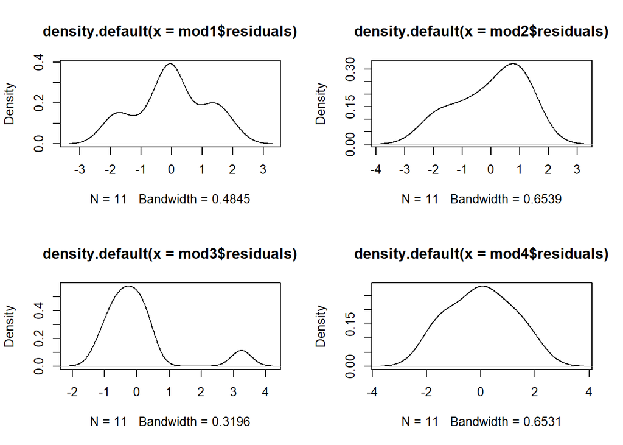

```r
par(mfrow = c(2,2))

# pour y1 sur x1 :
plot(density(mod1$residuals))

# pour y2 sur x2 :
plot(density(mod2$residuals))

# pour y3 sur x3 :
plot(density(mod3$residuals))

# pour y4 sur x4 :
plot(density(mod4$residuals))
```

```r
par(mfrow = c(1,1))
```

**Bonus** : `plot(mon_modele)` donne directement quelques plots informatifs sur la qualité de votre régression. Exemples :

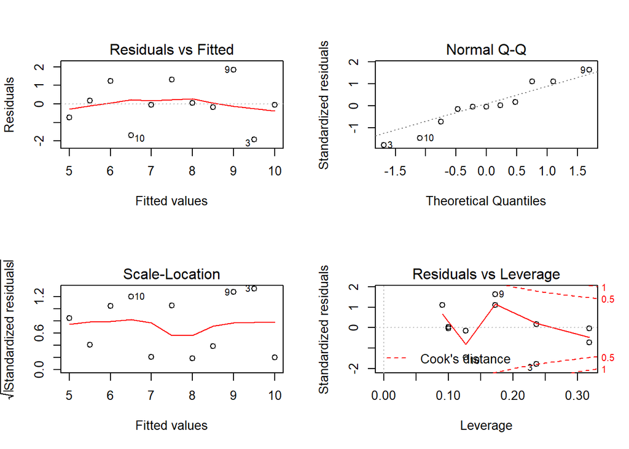

```r
par(mfrow=c(2,2)) # Change the panel layout to 2 x 2
plot(mod1)
```

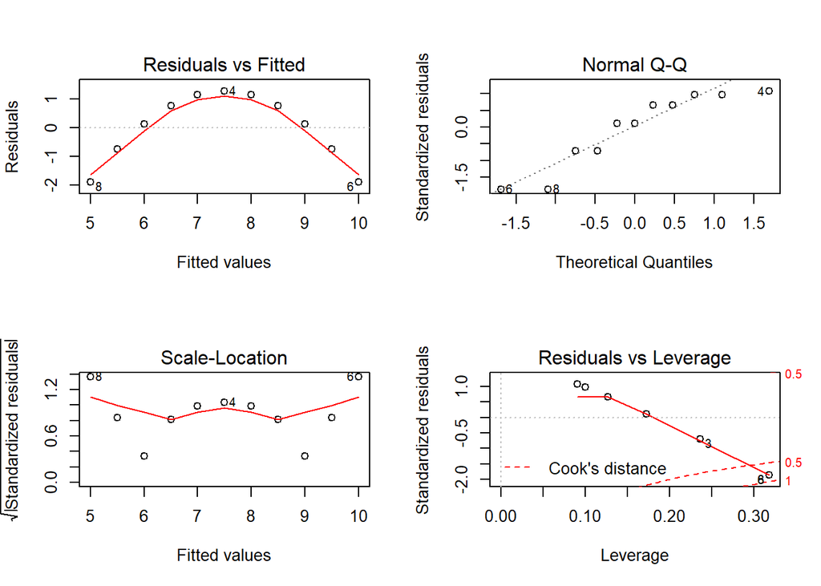

```r
plot(mod2)
```

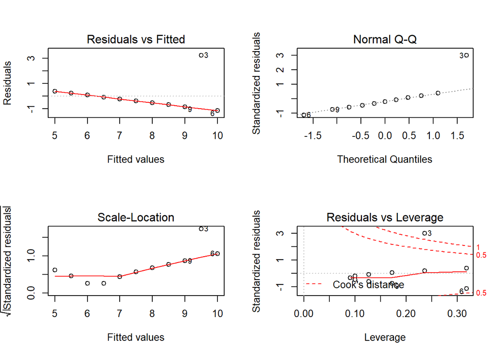

```r
plot(mod3)
```

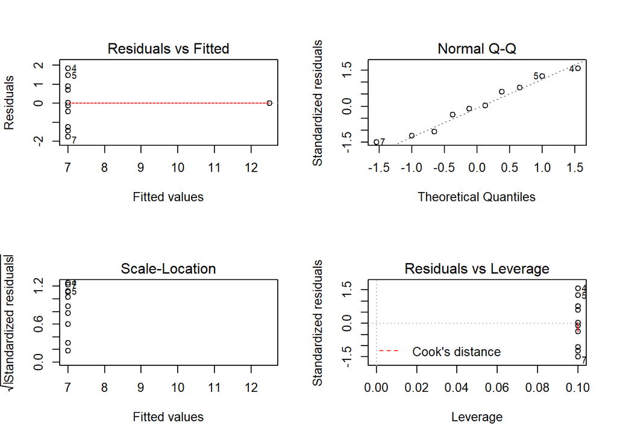

```r
plot(mod4)
```

```r
par(mfrow=c(1,1))
```

## Import des données et pré-traitements

Pour cette partie on part de la base fusionnée de `flights` et `weather` sans avoir agrégé flights auparavant, que l’on obtient ainsi :

```r
library(nycflights13)
library(dplyr)
flights_weather <- flights %>% inner_join(weather, by = c("time_hour", "origin"))
```

On cherche ici à expliquer le retard au départ `dep_delay` en fonction de différents indicateurs météo.

1. Créez une table `flights_weather_nona` où vous retirez les observations ayant des valeurs manquantes pour la variable `dep_delay`.

**Correction** : Par exemple, avec `dplyr` :

```r
flights_weather_nona <- flights_weather %>% filter(!is.na(dep_delay))
```

## Régressions linéaires simples

Dans cette partie on étudie l’impact de chaque variable météo sur le retard au départ en régressant notre variable expliquée `dep_delay` sur chacune de nos variables explicatives.  
1. Faites une régression de `dep_delay` sur la variable `temp`. Commentez le coefficient obtenu. Comment s’interprète-t-il? Commentez les valeurs de la p-value et du R2. Que représentent-ils?

**Correction** : Ici par exemple, le coefficient de la température est de 0.1381645, ce qui signifie qu’une augmentation de la température de 1 fahrenheit augmente en moyenne le retard de 0.1381645 minute. Ce coefficient est significativement différent de 0 à moins de 0.1%. Le R2 associé est de 0.4% environ.

```r
summary(lm(data = flights_weather_nona, dep_delay ~ temp))
```

```
##
## Call:
## lm(formula = dep_delay ~ temp, data = flights_weather_nona)
##
## Residuals:
##     Min      1Q  Median      3Q     Max
##  -52.45  -17.85  -13.66   -1.72 1290.03
##
## Coefficients:
##             Estimate Std. Error t value Pr(>|t|)
## (Intercept) 4.755813   0.234425   20.29   <2e-16 ***
## temp        0.138165   0.003922   35.23   <2e-16 ***
## ---
## Signif. codes:  0 '***' 0.001 '**' 0.01 '*' 0.05 '.' 0.1 ' ' 1
##
## Residual standard error: 40.15 on 326974 degrees of freedom
##   (17 observations deleted due to missingness)
## Multiple R-squared:  0.003781,   Adjusted R-squared:  0.003778
## F-statistic:  1241 on 1 and 326974 DF,  p-value: < 2.2e-16
```

2. Mêmes questions avec la variable `humid` comme variable explicative.
3. Mêmes questions avec la variable `precip` comme variable explicative.
4. Mêmes questions avec la variable `pressure` comme variable explicative.
5. Mêmes questions avec la variable `visib` comme variable explicative.
6. Mêmes questions avec la variable `wind_speed` comme variable explicative.

**Correction** : Les autres sorties, à commenter sur le même principe :

```r
summary(lm(data = flights_weather_nona, dep_delay ~ humid))
```

```
##
## Call:
## lm(formula = dep_delay ~ humid, data = flights_weather_nona)
##
## Residuals:
##     Min      1Q  Median      3Q     Max
##  -52.74  -18.16  -12.55   -1.07 1284.90
##
## Coefficients:
##             Estimate Std. Error t value Pr(>|t|)
## (Intercept) -1.66875    0.22267  -7.494 6.68e-14 ***
## humid        0.24150    0.00357  67.654  < 2e-16 ***
## ---
## Signif. codes:  0 '***' 0.001 '**' 0.01 '*' 0.05 '.' 0.1 ' ' 1
##
## Residual standard error: 39.95 on 326974 degrees of freedom
##   (17 observations deleted due to missingness)
## Multiple R-squared:  0.0138, Adjusted R-squared:  0.0138
## F-statistic:  4577 on 1 and 326974 DF,  p-value: < 2.2e-16
```

```r
summary(lm(data = flights_weather_nona, dep_delay ~ precip))
```

```
##
## Call:
## lm(formula = dep_delay ~ precip, data = flights_weather_nona)
##
## Residuals:
##     Min      1Q  Median      3Q     Max
## -161.49  -17.12  -14.12   -2.12 1288.88
##
## Coefficients:
##              Estimate Std. Error t value Pr(>|t|)
## (Intercept)  12.11526    0.07077  171.19   <2e-16 ***
## precip      122.62710    2.36248   51.91   <2e-16 ***
## ---
## Signif. codes:  0 '***' 0.001 '**' 0.01 '*' 0.05 '.' 0.1 ' ' 1
##
## Residual standard error: 40.06 on 326991 degrees of freedom
## Multiple R-squared:  0.008172,   Adjusted R-squared:  0.008169
## F-statistic:  2694 on 1 and 326991 DF,  p-value: < 2.2e-16
```

```r
summary(lm(data = flights_weather_nona, dep_delay ~ pressure))
```

```
##
## Call:
## lm(formula = dep_delay ~ pressure, data = flights_weather_nona)
##
## Residuals:
##     Min      1Q  Median      3Q     Max
##  -48.83  -16.65  -11.60   -1.28 1296.31
##
## Coefficients:
##               Estimate Std. Error t value Pr(>|t|)
## (Intercept) 601.850687   9.503645   63.33   <2e-16 ***
## pressure     -0.580331   0.009336  -62.16   <2e-16 ***
## ---
## Signif. codes:  0 '***' 0.001 '**' 0.01 '*' 0.05 '.' 0.1 ' ' 1
##
## Residual standard error: 37.45 on 292200 degrees of freedom
##   (34791 observations deleted due to missingness)
## Multiple R-squared:  0.01305,    Adjusted R-squared:  0.01305
## F-statistic:  3864 on 1 and 292200 DF,  p-value: < 2.2e-16
```

```r
summary(lm(data = flights_weather_nona, dep_delay ~ visib))
```

```
##
## Call:
## lm(formula = dep_delay ~ visib, data = flights_weather_nona)
##
## Residuals:
##     Min      1Q  Median      3Q     Max
##  -54.27  -17.27  -13.27   -1.27 1285.90
##
## Coefficients:
##             Estimate Std. Error t value Pr(>|t|)
## (Intercept) 30.39339    0.33587   90.49   <2e-16 ***
## visib       -1.91190    0.03537  -54.06   <2e-16 ***
## ---
## Signif. codes:  0 '***' 0.001 '**' 0.01 '*' 0.05 '.' 0.1 ' ' 1
##
## Residual standard error: 40.05 on 326991 degrees of freedom
## Multiple R-squared:  0.008858,   Adjusted R-squared:  0.008855
## F-statistic:  2922 on 1 and 326991 DF,  p-value: < 2.2e-16
```

```r
summary(lm(data = flights_weather_nona, dep_delay ~ wind_speed))
```

```
##
## Call:
## lm(formula = dep_delay ~ wind_speed, data = flights_weather_nona)
##
## Residuals:
##     Min      1Q  Median      3Q     Max
##  -55.00  -17.60  -13.81   -1.82 1290.59
##
## Coefficients:
##             Estimate Std. Error t value Pr(>|t|)
## (Intercept)   8.8233     0.1571   56.17   <2e-16 ***
## wind_speed    0.3448     0.0127   27.15   <2e-16 ***
## ---
## Signif. codes:  0 '***' 0.001 '**' 0.01 '*' 0.05 '.' 0.1 ' ' 1
##
## Residual standard error: 40.18 on 326913 degrees of freedom
##   (78 observations deleted due to missingness)
## Multiple R-squared:  0.002249,   Adjusted R-squared:  0.002246
## F-statistic: 736.9 on 1 and 326913 DF,  p-value: < 2.2e-16
```

7. Mêmes questions avec la variable `wind_gust` comme variable explicative.  
   **Correction** : On s’arrête un peu sur la variable `wind_gust`, car elle a beaucoup de valeurs manquantes. Elle représente les vitesses des rafales mais est donc mise en NA quand il n’y a pas de rafale. Si on fait la régression naïvement, elle va elle-même ignorer les valeurs manquantes :

```r
summary(lm(data = flights_weather_nona, dep_delay ~ wind_gust))
```

```
##
## Call:
## lm(formula = dep_delay ~ wind_gust, data = flights_weather_nona)
##
## Residuals:
##    Min     1Q Median     3Q    Max
## -48.95 -18.44 -14.44  -0.68 798.29
##
## Coefficients:
##             Estimate Std. Error t value Pr(>|t|)
## (Intercept)  6.56809    0.63173   10.40   <2e-16 ***
## wind_gust    0.28201    0.02445   11.53   <2e-16 ***
## ---
## Signif. codes:  0 '***' 0.001 '**' 0.01 '*' 0.05 '.' 0.1 ' ' 1
##
## Residual standard error: 40.38 on 77732 degrees of freedom
##   (249259 observations deleted due to missingness)
## Multiple R-squared:  0.001708,   Adjusted R-squared:  0.001695
## F-statistic:   133 on 1 and 77732 DF,  p-value: < 2.2e-16
```

Mais il serait légitime de dire que les valeurs manquantes s’apparentent plutôt ici à des 0, et on obtiendrait alors :

```r
flights_weather_nona <- flights_weather_nona %>%
  mutate(wind_gust_bis = replace(wind_gust, is.na(wind_gust), 0)) # on remplace par 0 avec replace()

summary(lm(data = flights_weather_nona, dep_delay ~ wind_gust_bis))
```

```
##
## Call:
## lm(formula = dep_delay ~ wind_gust_bis, data = flights_weather_nona)
##
## Residuals:
##     Min      1Q  Median      3Q     Max
##  -55.22  -17.22  -14.22   -2.22 1288.78
##
## Coefficients:
##                Estimate Std. Error t value Pr(>|t|)
## (Intercept)   12.223426   0.079906  152.97   <2e-16 ***
## wind_gust_bis  0.068919   0.006344   10.86   <2e-16 ***
## ---
## Signif. codes:  0 '***' 0.001 '**' 0.01 '*' 0.05 '.' 0.1 ' ' 1
##
## Residual standard error: 40.22 on 326991 degrees of freedom
## Multiple R-squared:  0.0003608,  Adjusted R-squared:  0.0003577
## F-statistic:   118 on 1 and 326991 DF,  p-value: < 2.2e-16
```

## Régression linéaire multiple

La régression linéaire multiple, comme son nom l’indique, consiste à intégrer non pas une mais plusieurs variables explicatives.  
1. Repartez de la régression de `dep_delay` sur `temp` puis ajoutez progressivement les variables `humid`, `precip`, `pressure`, `visib`, `wind_speed`, `wind_gust`. À chaque étape (une étape = un ajout d’une nouvelle variables), commentez les évolutions des coefficients, de leurs p-value et du R2. Pourquoi les coefficients ne sont pas les mêmes que dans les régressions linéaires simples?

**Correction** : Les coefficients évoluent ainsi :

```r
summary(lm(data = flights_weather_nona, dep_delay ~ temp + humid))
```

```
##
## Call:
## lm(formula = dep_delay ~ temp + humid, data = flights_weather_nona)
##
## Residuals:
##     Min      1Q  Median      3Q     Max
##  -49.87  -18.41  -12.24   -0.87 1286.50
##
## Coefficients:
##              Estimate Std. Error t value Pr(>|t|)
## (Intercept) -8.637992   0.308218  -28.03   <2e-16 ***
## temp         0.127291   0.003899   32.65   <2e-16 ***
## humid        0.236604   0.003567   66.33   <2e-16 ***
## ---
## Signif. codes:  0 '***' 0.001 '**' 0.01 '*' 0.05 '.' 0.1 ' ' 1
##
## Residual standard error: 39.88 on 326973 degrees of freedom
##   (17 observations deleted due to missingness)
## Multiple R-squared:  0.01701,    Adjusted R-squared:  0.017
## F-statistic:  2829 on 2 and 326973 DF,  p-value: < 2.2e-16
```

```r
summary(lm(data = flights_weather_nona, dep_delay ~ temp + humid + precip))
```

```
##
## Call:
## lm(formula = dep_delay ~ temp + humid + precip, data = flights_weather_nona)
##
## Residuals:
##     Min      1Q  Median      3Q     Max
## -131.89  -18.05  -12.23   -0.95 1287.35
##
## Coefficients:
##              Estimate Std. Error t value Pr(>|t|)
## (Intercept) -7.129295   0.310186  -22.98   <2e-16 ***
## temp         0.127298   0.003891   32.72   <2e-16 ***
## humid        0.204660   0.003660   55.92   <2e-16 ***
## precip      90.427935   2.414645   37.45   <2e-16 ***
## ---
## Signif. codes:  0 '***' 0.001 '**' 0.01 '*' 0.05 '.' 0.1 ' ' 1
##
## Residual standard error: 39.8 on 326972 degrees of freedom
##   (17 observations deleted due to missingness)
## Multiple R-squared:  0.02121,    Adjusted R-squared:  0.0212
## F-statistic:  2361 on 3 and 326972 DF,  p-value: < 2.2e-16
```

```r
summary(lm(data = flights_weather_nona, dep_delay ~ temp + humid + precip + pressure))
```

```
##
## Call:
## lm(formula = dep_delay ~ temp + humid + precip + pressure, data = flights_weather_nona)
##
## Residuals:
##     Min      1Q  Median      3Q     Max
##  -77.81  -16.87  -11.31   -0.82 1294.19
##
## Coefficients:
##               Estimate Std. Error t value Pr(>|t|)
## (Intercept) 473.708179   9.981126   47.46   <2e-16 ***
## temp          0.091558   0.003945   23.21   <2e-16 ***
## humid         0.120446   0.003943   30.55   <2e-16 ***
## precip       98.425669   5.599212   17.58   <2e-16 ***
## pressure     -0.466353   0.009720  -47.98   <2e-16 ***
## ---
## Signif. codes:  0 '***' 0.001 '**' 0.01 '*' 0.05 '.' 0.1 ' ' 1
##
## Residual standard error: 37.32 on 292197 degrees of freedom
##   (34791 observations deleted due to missingness)
## Multiple R-squared:  0.01988,    Adjusted R-squared:  0.01986
## F-statistic:  1481 on 4 and 292197 DF,  p-value: < 2.2e-16
```

```r
summary(lm(data = flights_weather_nona, dep_delay ~ temp + humid + precip + pressure + visib))
```

```
##
## Call:
## lm(formula = dep_delay ~ temp + humid + precip + pressure + visib,
##     data = flights_weather_nona)
##
## Residuals:
##     Min      1Q  Median      3Q     Max
##  -70.64  -16.81  -11.28   -0.84 1293.59
##
## Coefficients:
##               Estimate Std. Error t value Pr(>|t|)
## (Intercept) 475.961850   9.981761   47.68   <2e-16 ***
## temp          0.095318   0.003961   24.07   <2e-16 ***
## humid         0.100428   0.004398   22.83   <2e-16 ***
## precip       80.317127   5.869725   13.68   <2e-16 ***
## pressure     -0.462152   0.009727  -47.52   <2e-16 ***
## visib        -0.583768   0.056885  -10.26   <2e-16 ***
## ---
## Signif. codes:  0 '***' 0.001 '**' 0.01 '*' 0.05 '.' 0.1 ' ' 1
##
## Residual standard error: 37.31 on 292196 degrees of freedom
##   (34791 observations deleted due to missingness)
## Multiple R-squared:  0.02023,    Adjusted R-squared:  0.02021
## F-statistic:  1207 on 5 and 292196 DF,  p-value: < 2.2e-16
```

```r
summary(lm(data = flights_weather_nona, dep_delay ~ temp + humid + precip + pressure + visib + wind_speed))
```

```
##
## Call:
## lm(formula = dep_delay ~ temp + humid + precip + pressure + visib +
##     wind_speed, data = flights_weather_nona)
##
## Residuals:
##     Min      1Q  Median      3Q     Max
##  -68.07  -16.79  -11.19   -0.69 1294.43
##
## Coefficients:
##               Estimate Std. Error t value Pr(>|t|)
## (Intercept) 400.232896  10.572026   37.86   <2e-16 ***
## temp          0.113956   0.004050   28.14   <2e-16 ***
## humid         0.127545   0.004571   27.91   <2e-16 ***
## precip       75.029722   5.870607   12.78   <2e-16 ***
## pressure     -0.393228   0.010229  -38.44   <2e-16 ***
## visib        -0.615347   0.056870  -10.82   <2e-16 ***
## wind_speed    0.300750   0.013884   21.66   <2e-16 ***
## ---
## Signif. codes:  0 '***' 0.001 '**' 0.01 '*' 0.05 '.' 0.1 ' ' 1
##
## Residual standard error: 37.28 on 292131 degrees of freedom
##   (34855 observations deleted due to missingness)
## Multiple R-squared:  0.02181,    Adjusted R-squared:  0.02179
## F-statistic:  1086 on 6 and 292131 DF,  p-value: < 2.2e-16
```

```r
summary(lm(data = flights_weather_nona, dep_delay ~ temp + humid + precip + pressure + visib + wind_speed + wind_gust_bis))
```

```
##
## Call:
## lm(formula = dep_delay ~ temp + humid + precip + pressure + visib +
##     wind_speed + wind_gust_bis, data = flights_weather_nona)
##
## Residuals:
##     Min      1Q  Median      3Q     Max
##  -68.41  -16.80  -11.20   -0.68 1294.31
##
## Coefficients:
##                 Estimate Std. Error t value Pr(>|t|)
## (Intercept)   394.489465  10.700156  36.868  < 2e-16 ***
## temp            0.115453   0.004073  28.347  < 2e-16 ***
## humid           0.130900   0.004671  28.023  < 2e-16 ***
## precip         75.022859   5.870496  12.780  < 2e-16 ***
## pressure       -0.387784   0.010348 -37.473  < 2e-16 ***
## visib          -0.601736   0.057004 -10.556  < 2e-16 ***
## wind_speed      0.265464   0.017199  15.435  < 2e-16 ***
## wind_gust_bis   0.029652   0.008530   3.476 0.000509 ***
## ---
## Signif. codes:  0 '***' 0.001 '**' 0.01 '*' 0.05 '.' 0.1 ' ' 1
##
## Residual standard error: 37.28 on 292130 degrees of freedom
##   (34855 observations deleted due to missingness)
## Multiple R-squared:  0.02185,    Adjusted R-squared:  0.02183
## F-statistic: 932.3 on 7 and 292130 DF,  p-value: < 2.2e-16
```

Les coefficients ne sont pas les mêmes parce qu’on prend maintenant en compte leurs effets croisés. Chaque coefficient doit s’interpréter “toutes choses égales par ailleurs”. Par exemple, l’effet de la température baisse lorsqu’on inclut la pression atmosphérique car les deux variables sont corrélées. ce résultat s’interprète comme “à pression atmosphérique constante, l’effet de la température sur le retard des avions est moins important que si l’on ne contrôle pas par celle-ci”. De la même manière, on s’apperçoit que l’effet des précipitations sur le retard est fortement lié au manque de visibilité qui en découle puisque quand on intègre la visibilité l’effet propre des précipitations diminue.

2. En repartant de la table `flights_weather` qui contient les valeurs manquantes de `dep_delay`, sortez les moyennes des variables météo lorsque `dep_delay` est manquante et lorsqu’elle est renseignée. Constatez-vous des différences?  
   *Indices* : On peut tout d’abord créer une variable `delay_manquante` égale à 1 si `dep_delay` est manquante, 0 sinon. Pour cela, la fonction `if_else` de `dplyr` peut vous être utile. Ensuite, il n’y a plus qu’à faire les moyennes de ces variables groupées par cette variable.

**Correction** :

```r
flights_weather %>% mutate(delay_manquante = if_else(is.na(dep_delay), 1, 0)) %>%
  group_by(delay_manquante) %>%
  summarise_at(vars(temp, humid, precip, pressure, visib, wind_speed, wind_gust), mean, na.rm = T)
```

| delay_manquante | temp | humid | precip | pressure | visib | wind_speed | wind_gust |
| --- | --- | --- | --- | --- | --- | --- | --- |
| 0 | 57.02808 | 59.22925 | 0.004241589 | 1017.893 | 9.288140 | 11.06171 | 25.14481 |
| 1 | 55.74037 | 72.59888 | 0.017370852 | 1013.504 | 7.964528 | 13.20369 | 28.21690 |

ce sindications météo, si on les compare aux effets des variables météo sur le retard des avions, semblent indiquer de mauvaises conditions de vol. On peut en déduire que les valeurs manquantes sont sans doute des vols annulés.

3. Retour à la régression : regardez si la distance du vol a un impact sur le retard au départ, lorsque l’on contrôle par les variables météo.

**Correction** :

```r
summary(lm(data = flights_weather_nona,
           dep_delay ~ temp + humid + precip + pressure + visib +
             wind_speed + wind_gust_bis + distance))
```

```
##
## Call:
## lm(formula = dep_delay ~ temp + humid + precip + pressure + visib +
##     wind_speed + wind_gust_bis + distance, data = flights_weather_nona)
##
## Residuals:
##     Min      1Q  Median      3Q     Max
##  -67.87  -16.84  -11.13   -0.58 1297.97
##
## Coefficients:
##                 Estimate Std. Error t value Pr(>|t|)
## (Intercept)    3.931e+02  1.070e+01  36.745  < 2e-16 ***
## temp           1.160e-01  4.073e-03  28.486  < 2e-16 ***
## humid          1.330e-01  4.675e-03  28.451  < 2e-16 ***
## precip         7.494e+01  5.870e+00  12.768  < 2e-16 ***
## pressure      -3.858e-01  1.035e-02 -37.276  < 2e-16 ***
## visib         -5.978e-01  5.700e-02 -10.488  < 2e-16 ***
## wind_speed     2.727e-01  1.721e-02  15.846  < 2e-16 ***
## wind_gust_bis  2.773e-02  8.531e-03   3.250  0.00115 **
## distance      -9.324e-04  9.397e-05  -9.922  < 2e-16 ***
## ---
## Signif. codes:  0 '***' 0.001 '**' 0.01 '*' 0.05 '.' 0.1 ' ' 1
##
## Residual standard error: 37.28 on 292129 degrees of freedom
##   (34855 observations deleted due to missingness)
## Multiple R-squared:  0.02218,    Adjusted R-squared:  0.02215
## F-statistic: 828.3 on 8 and 292129 DF,  p-value: < 2.2e-16
```

Si la distance en miles augmente de 1, le retard diminue de 0.0009 minute. De manière équivalente, si la distance augmente de 1000 miles, le retard diminue de 0.9 minute. L’effet est significatif d’après la p-value, mais relativement faible.

4. Après avoir converti la variable `origin` en `factor` avec `as.factor`, regardez si l’aéroport d’origine a un effet sur le retard au départ, lorsqu’on contrôle par la distance du vol et les variables météo.

**Correction** :

```r
summary(lm(data = flights_weather_nona,
           dep_delay ~ temp + humid + precip + pressure + visib +
             wind_speed + wind_gust_bis + distance + as.factor(origin)))
```

```
##
## Call:
## lm(formula = dep_delay ~ temp + humid + precip + pressure + visib +
##     wind_speed + wind_gust_bis + distance + as.factor(origin),
##     data = flights_weather_nona)
##
## Residuals:
##     Min      1Q  Median      3Q     Max
##  -65.97  -16.77  -10.91   -0.52 1300.21
##
## Coefficients:
##                        Estimate Std. Error t value Pr(>|t|)
## (Intercept)           3.913e+02  1.071e+01  36.541   <2e-16 ***
## temp                  1.165e-01  4.067e-03  28.654   <2e-16 ***
## humid                 1.327e-01  4.722e-03  28.097   <2e-16 ***
## precip                7.398e+01  5.860e+00  12.624   <2e-16 ***
## pressure             -3.816e-01  1.035e-02 -36.856   <2e-16 ***
## visib                -6.018e-01  5.692e-02 -10.572   <2e-16 ***
## wind_speed            3.558e-01  1.782e-02  19.970   <2e-16 ***
## wind_gust_bis         3.660e-04  8.650e-03   0.042    0.966
## distance             -1.209e-03  9.717e-05 -12.440   <2e-16 ***
## as.factor(origin)JFK -3.642e+00  1.739e-01 -20.949   <2e-16 ***
## as.factor(origin)LGA -5.120e+00  1.724e-01 -29.694   <2e-16 ***
## ---
## Signif. codes:  0 '***' 0.001 '**' 0.01 '*' 0.05 '.' 0.1 ' ' 1
##
## Residual standard error: 37.21 on 292127 degrees of freedom
##   (34855 observations deleted due to missingness)
## Multiple R-squared:  0.02537,    Adjusted R-squared:  0.02534
## F-statistic: 760.5 on 10 and 292127 DF,  p-value: < 2.2e-16
```

Le fait de partir de JFK baisse le retard au départ de 3.6 minutes en moyenne par rapport à EWR, et de partir de LGA par rapport à EWR baisse le retard de 5,1 minutes.

5. À partir de ce que vous avez déjà fait, construisez un modèle de prédiction du retard au départ. Évaluez ses performances sur votre base de données en créant un échantillon d’entraînement et un échantillon de test.

**Correction** :

```r
# On crée un échantillon de test et un échantillon d'entraînement :
coeff = 0.8
train <- sample(seq_len(nrow(flights_weather_nona)), size = coeff * nrow(flights_weather_nona))
flight_train <- flights_weather_nona[train, ]
flights_test <- flights_weather_nona[-train, ]

my_model_train <- lm(data = flight_train,
                     dep_delay ~ temp + humid + precip + pressure + visib +
                      wind_speed + distance + as.factor(origin))

flights_test$delay_pred <- predict(my_model_train, newdata = flights_test)

flights_test %>% mutate(error_squared = abs(delay_pred - dep_delay)) %>%
  summarise_at(vars(error_squared),
               list(moy = mean, min = min, med = median, max = max, sd = sd), na.rm = T)
```

| moy | min | med | max | sd |
| --- | --- | --- | --- | --- |
| 20.98839 | 0.0007260075 | 14.41479 | 843.7278 | 30.78095 |

**Bonus validation croisée**  
On peut utiliser une méthode de *K-fold cross-validation* qui consiste à partitionner la base de données en k sous ensembles, et de tester l’erreur du modèle en entraînant le modèle k fois, en laissant comme échantillon de test à chaque fois un sous-ensemble différent. Le package `caret` permet de le faire facilement :

```r
train.control <- caret::trainControl(method = "cv", number = 10)

# On entraîne le modèle
model_cv <- caret::train(dep_delay ~ temp + humid + precip + pressure + visib +
                        wind_speed + distance + as.factor(origin),
                      data = flights_weather_nona,
                      na.action  = na.pass,
                      method = "lm",
                      trControl = train.control)
# On affiche les résultats
print(model_cv)
```

```
## Linear Regression
##
## 326993 samples
##      8 predictor
##
## No pre-processing
## Resampling: Cross-Validated (10 fold)
## Summary of sample sizes: 294294, 294294, 294293, 294293, 294293, 294295, ...
## Resampling results:
##
##   RMSE      Rsquared    MAE
##   37.20942  0.02534369  20.92543
##
## Tuning parameter 'intercept' was held constant at a value of TRUE
```